# Bike Demand Rental Prediction

## 1.1 - Problem Formulation, Data Acquisition and Preparation

### Problem Formulation

- The problem statement for this project is "How can predictive modelling be used to understand and forecast hourly bike rental demand based on environmental and temporal factors?".

### Data Acquisition

- From the UC Irvine Machine Learning Repository, the link to the dataset: https://archive.ics.uci.edu/dataset/560/seoul+bike+sharing+demand (UCI Machine Learning Repository, 2020)

### Data Preparation

```python
# Import library, load dataset into dataframe, display dataset to understand the dataset structure.
import pandas as pd
df = pd.read_csv("SeoulBikeData.csv", encoding="unicode_escape")
df
```

|  | Date | Rented Bike Count | Hour | Temperature(°C) | Humidity(%) | Wind speed (m/s) | Visibility (10m) | Dew point temperature(°C) | Solar Radiation (MJ/m2) | Rainfall(mm) | Snowfall (cm) | Seasons | Holiday | Functioning Day |
| --- | --- | --- | --- | --- | --- | --- | --- | --- | --- | --- | --- | --- | --- | --- |
| 0 | 01/12/2017 | 254 | 0 | -5.2 | 37 | 2.2 | 2000 | -17.6 | 0.0 | 0.0 | 0.0 | Winter | No Holiday | Yes |
| 1 | 01/12/2017 | 204 | 1 | -5.5 | 38 | 0.8 | 2000 | -17.6 | 0.0 | 0.0 | 0.0 | Winter | No Holiday | Yes |
| 2 | 01/12/2017 | 173 | 2 | -6.0 | 39 | 1.0 | 2000 | -17.7 | 0.0 | 0.0 | 0.0 | Winter | No Holiday | Yes |
| 3 | 01/12/2017 | 107 | 3 | -6.2 | 40 | 0.9 | 2000 | -17.6 | 0.0 | 0.0 | 0.0 | Winter | No Holiday | Yes |
| 4 | 01/12/2017 | 78 | 4 | -6.0 | 36 | 2.3 | 2000 | -18.6 | 0.0 | 0.0 | 0.0 | Winter | No Holiday | Yes |
| ... | ... | ... | ... | ... | ... | ... | ... | ... | ... | ... | ... | ... | ... | ... |
| 8755 | 30/11/2018 | 1003 | 19 | 4.2 | 34 | 2.6 | 1894 | -10.3 | 0.0 | 0.0 | 0.0 | Autumn | No Holiday | Yes |
| 8756 | 30/11/2018 | 764 | 20 | 3.4 | 37 | 2.3 | 2000 | -9.9 | 0.0 | 0.0 | 0.0 | Autumn | No Holiday | Yes |
| 8757 | 30/11/2018 | 694 | 21 | 2.6 | 39 | 0.3 | 1968 | -9.9 | 0.0 | 0.0 | 0.0 | Autumn | No Holiday | Yes |
| 8758 | 30/11/2018 | 712 | 22 | 2.1 | 41 | 1.0 | 1859 | -9.8 | 0.0 | 0.0 | 0.0 | Autumn | No Holiday | Yes |
| 8759 | 30/11/2018 | 584 | 23 | 1.9 | 43 | 1.3 | 1909 | -9.3 | 0.0 | 0.0 | 0.0 | Autumn | No Holiday | Yes |

8760 rows × 14 columns

```python
# Column titles need to be reformatted, standardise column names
df.columns = (
    df.columns
      .str.strip()
      .str.lower()
      .str.replace(' ', '_', regex=False)
      .str.replace('(', '', regex=False)
      .str.replace(')', '', regex=False)
      .str.replace('%', 'pct', regex=False)
      .str.replace('/', '_per_', regex=False)
      .str.replace('.', '', regex=False)
      .str.replace ('°c', '', regex=False)
)

print(df.columns.to_list())
```

```
['date', 'rented_bike_count', 'hour', 'temperature', 'humiditypct', 'wind_speed_m_per_s', 'visibility_10m', 'dew_point_temperature', 'solar_radiation_mj_per_m2', 'rainfallmm', 'snowfall_cm', 'seasons', 'holiday', 'functioning_day']
```

```python
# Converting the data types of some columns
df['date'] = pd.to_datetime(df['date'], format='%d/%m/%Y')
df['holiday'] = df['holiday'].astype('category')
df['seasons'] = df['seasons'].astype('category')
df['functioning_day'] = df['functioning_day'].astype('category')

# We only want data from days that had functioning bike systems, then we can drop this column as it is no longer needed
df = df[df['functioning_day'] == 'Yes'].copy()
df.drop(columns='functioning_day', inplace=True)

# Dropping all duplicates and checking for missing values
dups = df.duplicated(subset=['date', 'hour'])
if dups.sum() > 0:
    df.drop_duplicates(subset=['date','hour'], inplace=True)
print(f"Number of exact duplicate date-hour rows: {dups.sum()}")
print("Missing values per column:")
print(df.isnull().sum())
```

```
Number of exact duplicate date-hour rows: 0
Missing values per column:
date                         0
rented_bike_count            0
hour                         0
temperature                  0
humiditypct                  0
wind_speed_m_per_s           0
visibility_10m               0
dew_point_temperature        0
solar_radiation_mj_per_m2    0
rainfallmm                   0
snowfall_cm                  0
seasons                      0
holiday                      0
dtype: int64
```

```python
# Confirm the final dataset structure
df
```

|  | date | rented_bike_count | hour | temperature | humiditypct | wind_speed_m_per_s | visibility_10m | dew_point_temperature | solar_radiation_mj_per_m2 | rainfallmm | snowfall_cm | seasons | holiday |
| --- | --- | --- | --- | --- | --- | --- | --- | --- | --- | --- | --- | --- | --- |
| 0 | 2017-12-01 | 254 | 0 | -5.2 | 37 | 2.2 | 2000 | -17.6 | 0.0 | 0.0 | 0.0 | Winter | No Holiday |
| 1 | 2017-12-01 | 204 | 1 | -5.5 | 38 | 0.8 | 2000 | -17.6 | 0.0 | 0.0 | 0.0 | Winter | No Holiday |
| 2 | 2017-12-01 | 173 | 2 | -6.0 | 39 | 1.0 | 2000 | -17.7 | 0.0 | 0.0 | 0.0 | Winter | No Holiday |
| 3 | 2017-12-01 | 107 | 3 | -6.2 | 40 | 0.9 | 2000 | -17.6 | 0.0 | 0.0 | 0.0 | Winter | No Holiday |
| 4 | 2017-12-01 | 78 | 4 | -6.0 | 36 | 2.3 | 2000 | -18.6 | 0.0 | 0.0 | 0.0 | Winter | No Holiday |
| ... | ... | ... | ... | ... | ... | ... | ... | ... | ... | ... | ... | ... | ... |
| 8755 | 2018-11-30 | 1003 | 19 | 4.2 | 34 | 2.6 | 1894 | -10.3 | 0.0 | 0.0 | 0.0 | Autumn | No Holiday |
| 8756 | 2018-11-30 | 764 | 20 | 3.4 | 37 | 2.3 | 2000 | -9.9 | 0.0 | 0.0 | 0.0 | Autumn | No Holiday |
| 8757 | 2018-11-30 | 694 | 21 | 2.6 | 39 | 0.3 | 1968 | -9.9 | 0.0 | 0.0 | 0.0 | Autumn | No Holiday |
| 8758 | 2018-11-30 | 712 | 22 | 2.1 | 41 | 1.0 | 1859 | -9.8 | 0.0 | 0.0 | 0.0 | Autumn | No Holiday |
| 8759 | 2018-11-30 | 584 | 23 | 1.9 | 43 | 1.3 | 1909 | -9.3 | 0.0 | 0.0 | 0.0 | Autumn | No Holiday |

8465 rows × 13 columns

## 1.2 - Exploration

### Question 1: What are the average and variability of hourly bike rentals per season, and how do they differ?

To find out the average and variability of bike rentals, we need to look at descriptive statistics. Average refers to the mean, and variability can be linked to how spread out the data is; in this case, the standard deviation and IQR spread.

```python
# Look at descriptive statistics for bike rental demand. Make sure to group by season specifically.
season_stats = df.groupby('seasons', observed=False)['rented_bike_count'].describe()

# Convert to new DataFrame
season_summary_df = (
    season_stats
    .reset_index()
    .rename(columns={'seasons': 'Season'})
    .sort_values(by='mean', ascending=False)
    .reset_index(drop=True)
)

season_summary_df
```

|  | Season | count | mean | std | min | 25% | 50% | 75% | max |
| --- | --- | --- | --- | --- | --- | --- | --- | --- | --- |
| 0 | Summer | 2208.0 | 1034.073370 | 690.244759 | 9.0 | 526.75 | 905.5 | 1442.5 | 3556.0 |
| 1 | Autumn | 1937.0 | 924.110480 | 617.547879 | 2.0 | 427.00 | 856.0 | 1271.0 | 3298.0 |
| 2 | Spring | 2160.0 | 746.254167 | 618.667962 | 2.0 | 225.00 | 599.0 | 1118.0 | 3251.0 |
| 3 | Winter | 2160.0 | 225.541204 | 150.372236 | 3.0 | 110.00 | 203.0 | 305.0 | 937.0 |

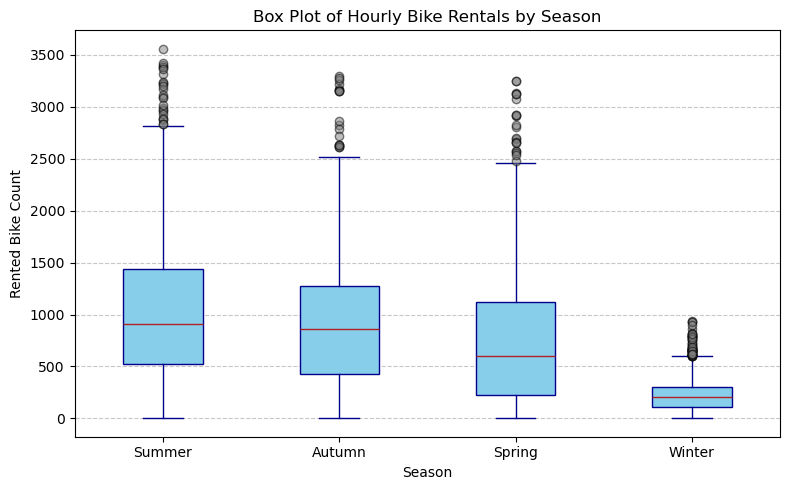

```python
import matplotlib.pyplot as plt

# Use the season_summary dataframe to create a variable with the seasons as a list
ordered_seasons = season_summary_df['Season'].tolist()

# Prepare box_data to be a list of four series objects
box_data = [
    df.loc[df['seasons'] == season, 'rented_bike_count']
    for season in ordered_seasons
]

# Visualise with a box plot to display average and variability (IQR range, outliers, mean).
plt.figure(figsize=(8, 5))
plt.boxplot(
    box_data,
    tick_labels=ordered_seasons,
    patch_artist=True,
    boxprops=dict(facecolor='skyblue', edgecolor='darkblue'),
    medianprops=dict(color='firebrick'),
    whiskerprops=dict(color='darkblue'),
    capprops=dict(color='darkblue'),
    flierprops=dict(marker='o', markerfacecolor='gray', alpha=0.5)
)
plt.title('Box Plot of Hourly Bike Rentals by Season')
plt.xlabel('Season')
plt.ylabel('Rented Bike Count')
plt.grid(axis='y', linestyle='--', alpha=0.7)
plt.tight_layout()
plt.show()
```

**Answer:**

### Question 2: What is the strength and direction of the relationship between temperature and hourly bike rental demand?

There are two ways we can tackle the strength and direction of a relationship. The easiest way is to first visualise the relationship of the data. Another way is to look at the Pearson correlation coefficient, which is related to the strength and direction of a relationship between two variables.

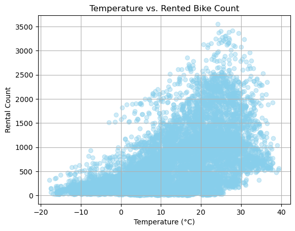

```
Correlation between temperature and rented bike count: 0.56
```

```python
# Visualise the relationship using a scatterplot to see the data points spread.
plt.scatter(df['temperature'], df['rented_bike_count'], alpha=0.4, color='skyblue')
plt.title('Temperature vs. Rented Bike Count')
plt.xlabel('Temperature (°C)')
plt.ylabel('Rental Count')
plt.grid(True)
plt.show()


# Now, we need to use descriptive statistics to quantify the correlation. This would involve using the Pearson correlation coefficient.
correlation = df['temperature'].corr(df['rented_bike_count'])
print(f"Correlation between temperature and rented bike count: {correlation:.2f}")
```

**Answer:**

- The scatterplot displays the direction of the relationship: a positive linear correlation; that is, as the temperature increases, rental count generally increases
- The Pearson correlation tells us more about the relationship. There is a moderate positive linear relationship between temperature and hourly bike rental demand, as the Pearson correlation was 0.56 (the range is between -1 and 1 where 1 is a perfect correlation).
- The reason for the moderate correlation may be that demand reaches a plateau and/or declines due to extreme temperatures and exercise discomfort.

### Question 3: What is the relationship between meteorological variables and bike demand? Identify which weather features are most correlated with demand.

We first need to pick out which weather features we are going to analyse with bike demand. We can use the Pearson correlation coefficient from 'Question 2', but now together with a correlation matrix and visualise all the weather features.

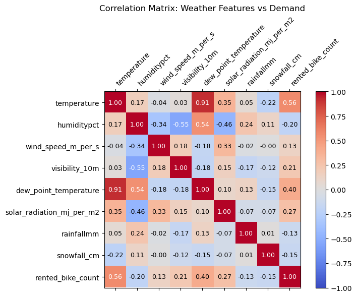

```python
# Pick out the specific weather features for the correlation matrix
weather_features = ['temperature', 'humiditypct', 'wind_speed_m_per_s',
                    'visibility_10m', 'dew_point_temperature', 'solar_radiation_mj_per_m2',
                    'rainfallmm', 'snowfall_cm']
all_columns = weather_features + ['rented_bike_count']

# Compute correlation matrix
corr_matrix = df[all_columns].corr()

# Visualise correlations as a correlation matrix with legend range on the right
fig, ax = plt.subplots(figsize=(8, 6))
cax = ax.matshow(corr_matrix, cmap='coolwarm', vmin=-1, vmax=1)
fig.colorbar(cax)

# Set tick labels
ax.set_xticks(range(len(all_columns)))
ax.set_xticklabels(all_columns, rotation=45, ha='left')
ax.set_yticks(range(len(all_columns)))
ax.set_yticklabels(all_columns)

# Annotate each cell with the correlation value (two decimal places)
for i in range(len(all_columns)):
    for j in range(len(all_columns)):
        value = corr_matrix.iloc[i, j]
        # Styling purposes
        text_color = 'white' if abs(value) > 0.5 else 'black'
        ax.text(
            j, i,
            f"{value:.2f}",
            ha='center', va='center',
            color=text_color,
            fontsize=9
        )
plt.title('Correlation Matrix: Weather Features vs Demand')
plt.tight_layout()
plt.show()
```

```python
# Sort weather features in descending order of Pearson correlation coefficient
corr_with_target = corr_matrix['rented_bike_count'].drop('rented_bike_count').sort_values(ascending=False)
corr_with_target
```

```
temperature                  0.562740
dew_point_temperature        0.400263
solar_radiation_mj_per_m2    0.273862
visibility_10m               0.212323
wind_speed_m_per_s           0.125022
rainfallmm                  -0.128626
snowfall_cm                 -0.151611
humiditypct                 -0.201973
Name: rented_bike_count, dtype: float64
```

**Answer:**

- The feature with the highest positive correlation with bike demand was temperature (0.56). This was followed by dew point temperature (0.40) and solar radiation (0.27).
- The feature with the highest negative correlation with bike demand was humidity (-0.20). This was followed by snowfall (-0.15) and rainfall (-0.13).
- Warm, sunny, and clear weather conditions drive the highest demand for bikes. The opposite can be seen where cold, wet, or humid conditions result in the least bike demand.

## 1.3 Feature Engineering and Unsupervised Learning

### Question: How can time periods be segmented into clusters that display similar weather conditions and compared to average bike demand?

Certain time periods can have similar weather conditions such as warm and sunny or cold and rainy. If we can identify these time periods, we can form clusters to then compare them to bike demand to see if we can use a regression model to forecast this.

```python
# Import required libraries
from sklearn.preprocessing import StandardScaler
from sklearn.cluster import KMeans
from sklearn.metrics import silhouette_score
```

The following weather features were chosen:

1. `temperature`
2. `humiditypct`
3. `wind_speed_m_per_s`
4. `visibility_10m`
5. `dew_point_temperature`
6. `solar_radiation_mj_per_m2`
7. `rainfallmm`
8. `snowfall_cm`

All 8 of these weather features were picked to reflect a full weather profile. We now have to standardise and combine the features in order to get the full picture of the clusters that represent specific weather regimes. That will then tell us more about bike demand. An extra thing that can be done to account for outliers and inaccuracy is by removing extreme weathers at the 99th percentile.

```python
# Selected weather features
cluster_features = [
    'temperature',
    'humiditypct',
    'wind_speed_m_per_s',
    'visibility_10m',
    'dew_point_temperature',
    'solar_radiation_mj_per_m2',
    'rainfallmm',
    'snowfall_cm'
]

# Creating a dataframe specific to these weather features
X_cluster = df[cluster_features].copy()

# Extreme precipitation values at the 99th percentile might cause outliers and inaccuracies. Thus, these will be removed.
precip_99 = X_cluster['rainfallmm'].quantile(0.99)
snow_99   = X_cluster['snowfall_cm'].quantile(0.99)
X_cluster['rainfallmm'] = X_cluster['rainfallmm'].clip(upper=precip_99)
X_cluster['snowfall_cm'] = X_cluster['snowfall_cm'].clip(upper=snow_99)

# Standardising all weather features, this standardising is different to the standardising later seen.
scaler = StandardScaler()
X_scaled = scaler.fit_transform(X_cluster)
```

**The Elbow Method**:

- For KMeans Clustering, we need to decide on the k value; that is, the optimal number of clusters. We can first test this with the Elbow Method.

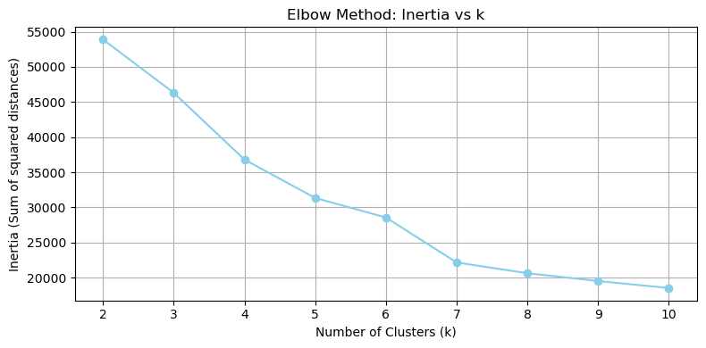

```python
# For the visualisation, the k range will be from 2 to 11 to fully see which value to choose.
K_range = range(2, 11)

# # For each k in K_range, fit KMeans on the scaled features and record both inertia and silhouette score
inertia    = []
sil_scores = []
for k in K_range:
    km        = KMeans(n_clusters=k, random_state=42)
    labels_k  = km.fit_predict(X_scaled)
    inertia.append(km.inertia_)
    sil_scores.append(silhouette_score(X_scaled, labels_k))

# Plot Elbow Method visualisation
plt.figure(figsize=(8, 4))
plt.plot(list(K_range), inertia, marker='o', color='skyblue')
plt.title('Elbow Method: Inertia vs k')
plt.xlabel('Number of Clusters (k)')
plt.ylabel('Inertia (Sum of squared distances)')
plt.grid(True)
plt.tight_layout()
plt.show()
```

**The Silhouette Score**:

- The Silhouette Score can also determine the optimal number of clusters, but it can also look at how well data points are categorised into their specific cluster. (scikit-learn, 2019)

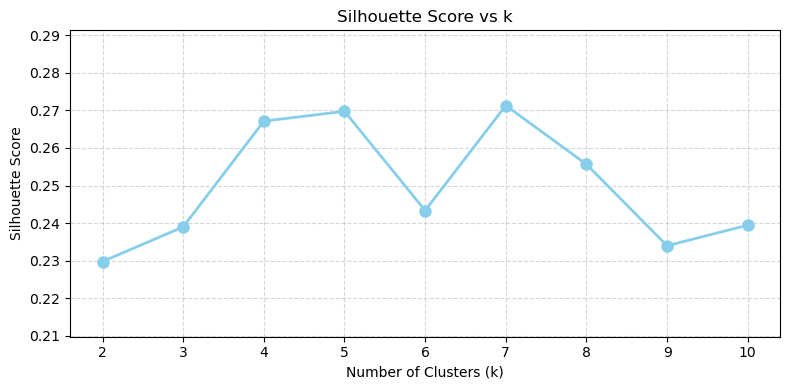

```python
# Plot Silhouette Score visualisation
plt.figure(figsize=(8, 4))
plt.plot(list(K_range), sil_scores,
         marker='o', color='skyblue',
         markersize=8, linewidth=2)
plt.title('Silhouette Score vs k')
plt.xlabel('Number of Clusters (k)')
plt.ylabel('Silhouette Score')

# Make the visualisation less cramped by expanding the y‐axis slightly
y_min = min(sil_scores) - 0.02
y_max = max(sil_scores) + 0.02
plt.ylim(y_min, y_max)

# Ensure every k is shown on the x‐axis
plt.xticks(list(K_range))

plt.grid(True, linestyle='--', alpha=0.5)
plt.tight_layout()
plt.show()
```

**K-Means Clustering:**

- Now, we want to visualise using K-Means Clustering. (scikit-learn, 2019) Since the Elbow Method and the Silhouette Scores gave us varying results, we can plot a range of k values to see whether introducing greater clusters will help.

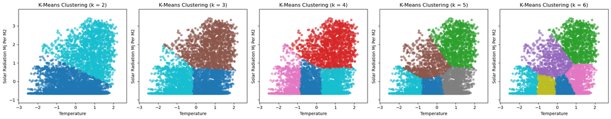

```python
# Rather than visualising just the suggested optimal k value (k=3), plotting the k values from 2 to 6 can better show the clustering features.
K_values = [2, 3, 4, 5, 6]

# Temperature and solar radiation were chosen as the weather features for the visualisation
x_feat = 'temperature'
y_feat = 'solar_radiation_mj_per_m2'

# The previous standardisation was for all the weather features; this standardisation is specific to the scatter plot for temperature and solar radiation.
X_plot = df[[x_feat, y_feat]].copy()
scaler_2d = StandardScaler()
X_plot_scaled = scaler_2d.fit_transform(X_plot)

# Instead of individually plotting each scatter plot, we can display it as a line of subplots for easier comparison.
ncols = len(K_values)
fig, axes = plt.subplots(nrows=1, ncols=ncols,
                         figsize=(4 * ncols, 4),
                         sharex=True, sharey=True)

# Compute common axis limits for plot alignment
x_min, x_max = X_plot_scaled[:, 0].min(), X_plot_scaled[:, 0].max()
y_min, y_max = X_plot_scaled[:, 1].min(), X_plot_scaled[:, 1].max()

# Loop over each k and its corresponding subplot to fit K-Means & scatter
for ax, k in zip(axes, K_values):
    # Fit K-Means to the 2D scaled data
    km        = KMeans(n_clusters=k, random_state=42)
    labels_k  = km.fit_predict(X_plot_scaled)

    # Scatter‐plot points colored by cluster label
    ax.scatter(
        X_plot_scaled[:, 0],
        X_plot_scaled[:, 1],
        c=labels_k,
        cmap='tab10',
        s=20,
        alpha=0.6
    )

    # Axis limits
    ax.set_xlim(x_min - 0.5, x_max + 0.5)
    ax.set_ylim(y_min - 0.5, y_max + 0.5)

    ax.set_title(f'K-Means Clustering (k = {k})', fontsize=12)
    ax.set_xlabel(f'{x_feat.title()}', fontsize=10)
    ax.set_ylabel(f'{y_feat.replace("_", " ").title()}', fontsize=10)

plt.tight_layout()
plt.show()
```

**Results:**

Thus, k = 3 balances coverage and clarity without too few or too many clusters.

## 1.4 Supervised Learning

The two machine learning algorithms chosen for this supervised learning are K-Nearest Neighbours (KNN) and Random Forests (RF).

```python
# Import relevant libraries
import numpy as np

from sklearn.model_selection import train_test_split, GridSearchCV
from sklearn.neighbors import KNeighborsRegressor
from sklearn.ensemble import RandomForestRegressor
from sklearn.metrics import mean_squared_error, r2_score
```

We first need to choose the feature predictors for our regression modelling. Then, we can split the data into 80% training and 20% testing. Our target feature is the bike demand (rented_bike_count).

```python
# Choose predictors. Exclude 'date' and the target 'rented_bike_count'.
features = [
    'hour',
    'temperature',
    'humiditypct',
    'wind_speed_m_per_s',
    'visibility_10m',
    'dew_point_temperature',
    'solar_radiation_mj_per_m2',
    'rainfallmm',
    'snowfall_cm',
]

X = df[features].copy()
y = df['rented_bike_count']

# Compute 99th percentile thresholds for rainfall and snowfall
precip_99 = X['rainfallmm'].quantile(0.99)
snow_99   = X['snowfall_cm'].quantile(0.99)

# Clip both columns to their 99th percentile
X['rainfallmm']  = X['rainfallmm'].clip(upper=precip_99)
X['snowfall_cm'] = X['snowfall_cm'].clip(upper=snow_99)

# 80% training + 20% testing
X_train, X_test, y_train, y_test = train_test_split(
    X, y, test_size=0.20, random_state=42
)

print(f"Training samples: {X_train.shape[0]}, Testing samples: {X_test.shape[0]}")
```

```
Training samples: 6772, Testing samples: 1693
```

We need to next scale the features.

```python
# Instantiate scaler and fit on training features
scaler = StandardScaler()
X_train_scaled = scaler.fit_transform(X_train)
X_test_scaled  = scaler.transform(X_test)
```

**K-Nearest Neighbours:**

- This is a distance-based machine learning algorithm that takes into account the average of its k nearest neighbours to forecast a data point. (GeeksforGeeks, 2024)
- GrindSearchCV will be used for hyperparameter tuning to determine the best parameter values. (Mujtaba, 2020)

```python
# Define KNN regressor and hyperparameter grid
knn = KNeighborsRegressor()

knn_param_grid = {
    'n_neighbors': [3, 5, 7, 9],
    'weights': ['uniform', 'distance'],
    'p': [1, 2]   # p=1 (Manhattan), p=2 (Euclidean)
}

# GridSearchCV hyperparameter tuning
knn_gs = GridSearchCV(
    estimator=knn,
    param_grid=knn_param_grid,
    scoring='neg_root_mean_squared_error',  # optimise for lowest RMSE
    cv=5,
    n_jobs=-1,
    verbose=2
)

# Fit GridSearchCV on the scaled training data
knn_gs.fit(X_train_scaled, y_train)

# Best hyperparameters and CV score (negative RMSE)
knn_best_params = knn_gs.best_params_
knn_best_cv_rmse = -knn_gs.best_score_  # convert to positive RMSE

print("KNN best parameters:", knn_best_params)
print("KNN best CV RMSE:", knn_best_cv_rmse)
```

```
Fitting 5 folds for each of 16 candidates, totalling 80 fits
KNN best parameters: {'n_neighbors': 9, 'p': 1, 'weights': 'distance'}
KNN best CV RMSE: 291.351153965567
```

**Random Forest:**

- This algorithm is a collection of decision trees that is trained on random data and feature subsets. (Shafi, 2023)
- GridSearchCV will once again be used for hyperparameter tuning.

```python
# Define Random Forest regressor and hyperparameter grid
rf = RandomForestRegressor(random_state=42)

rf_param_grid = {
    'n_estimators': [100, 200],
    'max_depth': [None, 10, 20],
    'min_samples_split': [2, 5],
    'max_features': ['sqrt', 0.5]
}

# GridSearchCV hyperparameter tuning
rf_gs = GridSearchCV(
    estimator=rf,
    param_grid=rf_param_grid,
    scoring='neg_root_mean_squared_error',  # optimize for lowest RMSE
    cv=5,
    n_jobs=-1,
    verbose=2
)

# Fit GridSearchCV on the scaled training data
rf_gs.fit(X_train_scaled, y_train)

# Best hyperparameters and CV score
rf_best_params    = rf_gs.best_params_
rf_best_cv_rmse   = -rf_gs.best_score_  # same thing as before, converting the RMSE to a positive value

print("RF best parameters:", rf_best_params)
print("RF best CV RMSE:", rf_best_cv_rmse)
```

```
Fitting 5 folds for each of 24 candidates, totalling 120 fits
RF best parameters: {'max_depth': 20, 'max_features': 0.5, 'min_samples_split': 2, 'n_estimators': 200}
RF best CV RMSE: 243.02616357985193
```

**Training-set hyperparameter summary table:**

- For better clarity, we can create a training-set hyperparameter summary table. This will display the model, best params, and CV RMSE.

```python
# Create a dataframe for the summary table
train_summary_df = pd.DataFrame({
    'Model': ['KNN Regressor', 'Random Forest Regressor'],
    'Best Params': [knn_best_params, rf_best_params],
    'CV RMSE': [knn_best_cv_rmse, rf_best_cv_rmse]
})

print("\n=== Hyperparameter Tuning Summary (Training CV) ===")
display(train_summary_df)
```

```
=== Hyperparameter Tuning Summary (Training CV) ===
```

|  | Model | Best Params | CV RMSE |
| --- | --- | --- | --- |
| 0 | KNN Regressor | {'n_neighbors': 9, 'p': 1, 'weights': 'distance'} | 291.351154 |
| 1 | Random Forest Regressor | {'max_depth': 20, 'max_features': 0.5, 'min_sa... | 243.026164 |

**Results:**

- Using the 80% training set, we can conclude that RF performed better than KNN as a lower cross-validated RMSE was reported (243.03 vs 291.35). Now, we can use the test set to evaluate the RF model further.

```python
# Retrieve the best estimators
best_knn = knn_gs.best_estimator_
best_rf  = rf_gs.best_estimator_

# Make predictions on scaled test set
y_pred_knn = best_knn.predict(X_test_scaled)
y_pred_rf  = best_rf.predict(X_test_scaled)

# Compute RMSE and R² for both models
rmse_knn = np.sqrt(mean_squared_error(y_test, y_pred_knn))
r2_knn   = r2_score(y_test, y_pred_knn)

rmse_rf = np.sqrt(mean_squared_error(y_test, y_pred_rf))
r2_rf   = r2_score(y_test, y_pred_rf)

# Test‐set performance
results_df = pd.DataFrame({
    'Model': ['KNN Regressor', 'Random Forest Regressor'],
    'Test RMSE': [rmse_knn, rmse_rf],
    'Test R²': [r2_knn, r2_rf]
})

print("\n=== Test‐Set Performance ===")
display(results_df)
```

```
=== Test‐Set Performance ===
```

|  | Model | Test RMSE | Test R² |
| --- | --- | --- | --- |
| 0 | KNN Regressor | 279.768451 | 0.800629 |
| 1 | Random Forest Regressor | 241.298248 | 0.851689 |

**Results:**

- From the test set, it can be concluded that Random Forest is the better algorithm over KNN.
- RF had a lower test RMSE (241.30 vs 279.77) and a higher R^2 (0.85 vs 0.80) compared to KNN.
- Having a higher R^2 means RF explains more of the variance in test-set demand (~85%).
- This means that, for example, if 1000 bikes are rented in a given hour, the model prediction would be off by roughly 241 bikes (prediction between 758 and 1242).

**Evaluation**:

- RF model has been compared to KNN. Now, we want to evaluate the model, especially the RMSE. The RMSE being 241 does not provide much information, as a 241 bike error might be trivial or huge relative to the natural variability. We now want to compare the test RMSE to the baselines RMSE to see how much better the model is compared to predicting the average. The fomula to calculate the baseline RMSE is written in the code comment. (Acharya, 2021)

```python
# Print overall mean hourly rental count from original dataset
overall_mean = df['rented_bike_count'].mean()
print(f"Overall mean hourly rental count: {overall_mean:.2f} bikes")

# Calculate baseline RMSE using previous overall mean
# sqrt(mean((y_true - overall_mean)^2) is the formula
baseline_rmse = np.sqrt(((df['rented_bike_count'] - overall_mean) ** 2).mean())
print(f"Baseline RMSE (predicting overall mean): {baseline_rmse:.2f} bikes")

# Random Forest RMSE calculated before
model_rmse = 241.30
print(f"Random Forest RMSE on test set: {model_rmse:.2f} bikes")

# Compare the Random Forest RMSE to the baseline RMSE calculated
improvement = (baseline_rmse - model_rmse) / baseline_rmse * 100
print(f"Improvement over baseline: {improvement:.1f}%")

# Calculating the normalised RMSE is calculating the model's typical error in relation to the average hourly rental
nrmse = model_rmse / overall_mean
print(f"NRMSE: {nrmse:.2f}   ({nrmse*100:.1f}% of average demand)")

# Summary dataframe
comparison_df = pd.DataFrame({
    'Metric': ['Overall Mean', 'Baseline RMSE', 'Model RMSE', 'Improvement (%)', 'NRMSE (%)'],
    'Value': [f"{overall_mean:.2f}",
              f"{baseline_rmse:.2f}",
              f"{model_rmse:.2f}",
              f"{improvement:.1f}%",
              f"{nrmse*100:.1f}%"]
})
print("\nSummary Comparison:")
display(comparison_df)
```

```
Overall mean hourly rental count: 729.16 bikes
Baseline RMSE (predicting overall mean): 642.31 bikes
Random Forest RMSE on test set: 241.30 bikes
Improvement over baseline: 62.4%
NRMSE: 0.33   (33.1% of average demand)

Summary Comparison:
```

|  | Metric | Value |
| --- | --- | --- |
| 0 | Overall Mean | 729.16 |
| 1 | Baseline RMSE | 642.31 |
| 2 | Model RMSE | 241.30 |
| 3 | Improvement (%) | 62.4% |
| 4 | NRMSE (%) | 33.1% |